# Risk Factor Analysis

## Outcome Variable

**Outcome Variable:** wasted

## Predictor Variables

**Intervention Variable:** mbmi

**Adjustment Set:**

- arm
- W_mage
- W_fage
- meducyrs
- feducyrs
- single
- brthmon
- delta_W_mage
- delta_W_fage
- delta_meducyrs
- delta_feducyrs
- delta_single
- delta_brthmon

## Stratifying Variables

The analysis was stratified on these variable(s):

- agecat
- studyid
- country

## Data Summary

| agecat | studyid | country | mbmi | wasted | n_cell | n |
| --- | --- | --- | --- | --- | --- | --- |
| Birth | ki0047075b-MAL-ED | BANGLADESH | Normal weight | 0 | 123 | 233 |
| Birth | ki0047075b-MAL-ED | BANGLADESH | Normal weight | 1 | 26 | 233 |
| Birth | ki0047075b-MAL-ED | BANGLADESH | Underweight | 0 | 21 | 233 |
| Birth | ki0047075b-MAL-ED | BANGLADESH | Underweight | 1 | 7 | 233 |
| Birth | ki0047075b-MAL-ED | BANGLADESH | Overweight or Obese | 0 | 50 | 233 |
| Birth | ki0047075b-MAL-ED | BANGLADESH | Overweight or Obese | 1 | 6 | 233 |
| Birth | ki0047075b-MAL-ED | BRAZIL | Normal weight | 0 | 66 | 176 |
| Birth | ki0047075b-MAL-ED | BRAZIL | Normal weight | 1 | 1 | 176 |
| Birth | ki0047075b-MAL-ED | BRAZIL | Underweight | 0 | 8 | 176 |
| Birth | ki0047075b-MAL-ED | BRAZIL | Underweight | 1 | 1 | 176 |
| Birth | ki0047075b-MAL-ED | BRAZIL | Overweight or Obese | 0 | 96 | 176 |
| Birth | ki0047075b-MAL-ED | BRAZIL | Overweight or Obese | 1 | 4 | 176 |
| Birth | ki0047075b-MAL-ED | INDIA | Normal weight | 0 | 96 | 195 |
| Birth | ki0047075b-MAL-ED | INDIA | Normal weight | 1 | 19 | 195 |
| Birth | ki0047075b-MAL-ED | INDIA | Underweight | 0 | 29 | 195 |
| Birth | ki0047075b-MAL-ED | INDIA | Underweight | 1 | 9 | 195 |
| Birth | ki0047075b-MAL-ED | INDIA | Overweight or Obese | 0 | 38 | 195 |
| Birth | ki0047075b-MAL-ED | INDIA | Overweight or Obese | 1 | 4 | 195 |
| Birth | ki0047075b-MAL-ED | NEPAL | Normal weight | 0 | 83 | 167 |
| Birth | ki0047075b-MAL-ED | NEPAL | Normal weight | 1 | 12 | 167 |
| Birth | ki0047075b-MAL-ED | NEPAL | Underweight | 0 | 0 | 167 |
| Birth | ki0047075b-MAL-ED | NEPAL | Underweight | 1 | 0 | 167 |
| Birth | ki0047075b-MAL-ED | NEPAL | Overweight or Obese | 0 | 64 | 167 |
| Birth | ki0047075b-MAL-ED | NEPAL | Overweight or Obese | 1 | 8 | 167 |
| Birth | ki0047075b-MAL-ED | PERU | Normal weight | 0 | 142 | 269 |
| Birth | ki0047075b-MAL-ED | PERU | Normal weight | 1 | 3 | 269 |
| Birth | ki0047075b-MAL-ED | PERU | Underweight | 0 | 5 | 269 |
| Birth | ki0047075b-MAL-ED | PERU | Underweight | 1 | 0 | 269 |
| Birth | ki0047075b-MAL-ED | PERU | Overweight or Obese | 0 | 116 | 269 |
| Birth | ki0047075b-MAL-ED | PERU | Overweight or Obese | 1 | 3 | 269 |

[output cut: 216 more lines]

The following strata were considered:

- agecat: 24 months, studyid: ki0047075b-MAL-ED, country: BANGLADESH
- agecat: 24 months, studyid: ki0047075b-MAL-ED, country: BRAZIL
- agecat: 24 months, studyid: ki0047075b-MAL-ED, country: INDIA
- agecat: 24 months, studyid: ki0047075b-MAL-ED, country: NEPAL
- agecat: 24 months, studyid: ki0047075b-MAL-ED, country: PERU
- agecat: 24 months, studyid: ki0047075b-MAL-ED, country: SOUTH AFRICA
- agecat: 24 months, studyid: ki0047075b-MAL-ED, country: TANZANIA, UNITED REPUBLIC OF
- agecat: 24 months, studyid: ki1017093-NIH-Birth, country: BANGLADESH
- agecat: 24 months, studyid: ki1017093b-PROVIDE, country: BANGLADESH
- agecat: 24 months, studyid: ki1017093c-NIH-Crypto, country: BANGLADESH
- agecat: 24 months, studyid: ki1066203-TanzaniaChild2, country: TANZANIA, UNITED REPUBLIC OF
- agecat: 24 months, studyid: ki1119695-PROBIT, country: BELARUS
- agecat: 24 months, studyid: ki1126311-ZVITAMBO, country: ZIMBABWE
- agecat: 24 months, studyid: ki1148112-LCNI-5, country: MALAWI
- agecat: 6 months, studyid: ki0047075b-MAL-ED, country: BANGLADESH
- agecat: 6 months, studyid: ki0047075b-MAL-ED, country: BRAZIL
- agecat: 6 months, studyid: ki0047075b-MAL-ED, country: INDIA
- agecat: 6 months, studyid: ki0047075b-MAL-ED, country: NEPAL
- agecat: 6 months, studyid: ki0047075b-MAL-ED, country: PERU
- agecat: 6 months, studyid: ki0047075b-MAL-ED, country: SOUTH AFRICA
- agecat: 6 months, studyid: ki0047075b-MAL-ED, country: TANZANIA, UNITED REPUBLIC OF
- agecat: 6 months, studyid: ki1000304b-SAS-CompFeed, country: INDIA
- agecat: 6 months, studyid: ki1017093-NIH-Birth, country: BANGLADESH
- agecat: 6 months, studyid: ki1017093b-PROVIDE, country: BANGLADESH
- agecat: 6 months, studyid: ki1017093c-NIH-Crypto, country: BANGLADESH
- agecat: 6 months, studyid: ki1066203-TanzaniaChild2, country: TANZANIA, UNITED REPUBLIC OF
- agecat: 6 months, studyid: ki1119695-PROBIT, country: BELARUS
- agecat: 6 months, studyid: ki1126311-ZVITAMBO, country: ZIMBABWE
- agecat: 6 months, studyid: ki1148112-LCNI-5, country: MALAWI
- agecat: Birth, studyid: ki0047075b-MAL-ED, country: BANGLADESH
- agecat: Birth, studyid: ki0047075b-MAL-ED, country: BRAZIL
- agecat: Birth, studyid: ki0047075b-MAL-ED, country: INDIA
- agecat: Birth, studyid: ki0047075b-MAL-ED, country: NEPAL
- agecat: Birth, studyid: ki0047075b-MAL-ED, country: PERU
- agecat: Birth, studyid: ki0047075b-MAL-ED, country: SOUTH AFRICA
- agecat: Birth, studyid: ki0047075b-MAL-ED, country: TANZANIA, UNITED REPUBLIC OF
- agecat: Birth, studyid: ki1000304b-SAS-CompFeed, country: INDIA
- agecat: Birth, studyid: ki1017093-NIH-Birth, country: BANGLADESH
- agecat: Birth, studyid: ki1017093c-NIH-Crypto, country: BANGLADESH
- agecat: Birth, studyid: ki1119695-PROBIT, country: BELARUS
- agecat: Birth, studyid: ki1126311-ZVITAMBO, country: ZIMBABWE

### Dropped Strata

Some strata were dropped due to rare outcomes:

- agecat: Birth, studyid: ki0047075b-MAL-ED, country: BRAZIL
- agecat: Birth, studyid: ki0047075b-MAL-ED, country: INDIA
- agecat: Birth, studyid: ki0047075b-MAL-ED, country: NEPAL
- agecat: Birth, studyid: ki0047075b-MAL-ED, country: PERU
- agecat: Birth, studyid: ki0047075b-MAL-ED, country: SOUTH AFRICA
- agecat: Birth, studyid: ki0047075b-MAL-ED, country: TANZANIA, UNITED REPUBLIC OF
- agecat: Birth, studyid: ki1000304b-SAS-CompFeed, country: INDIA
- agecat: Birth, studyid: ki1017093-NIH-Birth, country: BANGLADESH
- agecat: Birth, studyid: ki1017093c-NIH-Crypto, country: BANGLADESH
- agecat: 6 months, studyid: ki0047075b-MAL-ED, country: BANGLADESH
- agecat: 6 months, studyid: ki0047075b-MAL-ED, country: BRAZIL
- agecat: 6 months, studyid: ki0047075b-MAL-ED, country: INDIA
- agecat: 6 months, studyid: ki0047075b-MAL-ED, country: NEPAL
- agecat: 6 months, studyid: ki0047075b-MAL-ED, country: PERU
- agecat: 6 months, studyid: ki0047075b-MAL-ED, country: SOUTH AFRICA
- agecat: 6 months, studyid: ki0047075b-MAL-ED, country: TANZANIA, UNITED REPUBLIC OF
- agecat: 6 months, studyid: ki1017093-NIH-Birth, country: BANGLADESH
- agecat: 6 months, studyid: ki1017093b-PROVIDE, country: BANGLADESH
- agecat: 6 months, studyid: ki1017093c-NIH-Crypto, country: BANGLADESH
- agecat: 6 months, studyid: ki1066203-TanzaniaChild2, country: TANZANIA, UNITED REPUBLIC OF
- agecat: 6 months, studyid: ki1148112-LCNI-5, country: MALAWI
- agecat: 24 months, studyid: ki0047075b-MAL-ED, country: BANGLADESH
- agecat: 24 months, studyid: ki0047075b-MAL-ED, country: BRAZIL
- agecat: 24 months, studyid: ki0047075b-MAL-ED, country: INDIA
- agecat: 24 months, studyid: ki0047075b-MAL-ED, country: NEPAL
- agecat: 24 months, studyid: ki0047075b-MAL-ED, country: PERU
- agecat: 24 months, studyid: ki0047075b-MAL-ED, country: SOUTH AFRICA
- agecat: 24 months, studyid: ki0047075b-MAL-ED, country: TANZANIA, UNITED REPUBLIC OF
- agecat: 24 months, studyid: ki1017093-NIH-Birth, country: BANGLADESH
- agecat: 24 months, studyid: ki1017093c-NIH-Crypto, country: BANGLADESH
- agecat: 24 months, studyid: ki1066203-TanzaniaChild2, country: TANZANIA, UNITED REPUBLIC OF
- agecat: 24 months, studyid: ki1148112-LCNI-5, country: MALAWI

## Methods Detail

We’re interested in the causal parameters $E[Y_a]$ for all values of $a \in \mathcal{A}$. These parameters represent the mean outcome if, possibly contrary to fact, we intervened to set all units to have $A=a$. Under the randomization and positivity assumptions, these are identified by the statistical parameters $\psi_a=E_W[E_{Y|A,W}(Y|A=a,W)]$. In addition, we’re interested in the mean of $Y$, $E[Y]$ under no intervention (the observed mean). We will estimate these parameters by using SuperLearner to fit the relevant likelihood factors – $E_{Y|A,W}(Y|A=a,W)$ and $p(A=a|W)$, and then updating our likelihood fit using a joint TMLE.

For unadjusted analyses ($W=\{\}$), initial likelihoods were estimated using Lrnr_glm to estimate the simple $E(Y|A)$ and Lrnr_mean to estimate $p(A)$. For adjusted analyses, a small library containing Lrnr_glmnet, Lrnr_xgboost, and Lrnr_mean was used.

Having estimated these parameters, we will then use the delta method to estimate relative risks and attributable risks relative to a prespecified baseline level of $A$.

# Results Detail

## Results Plots

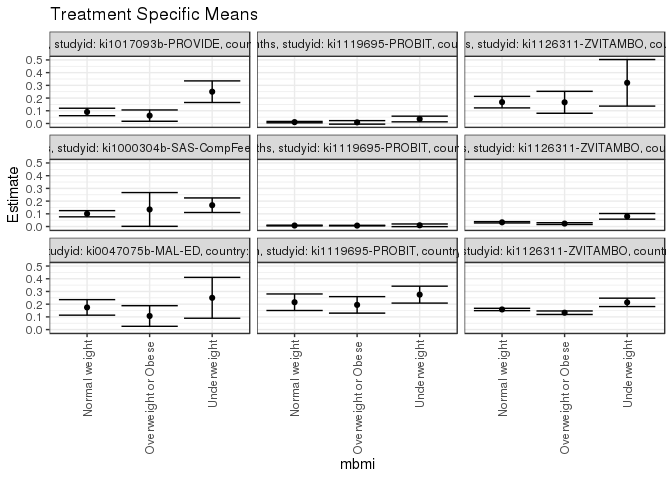

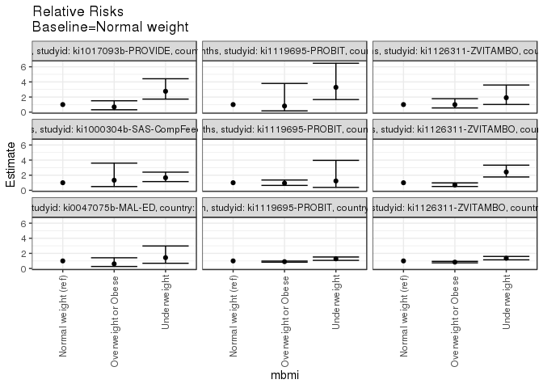

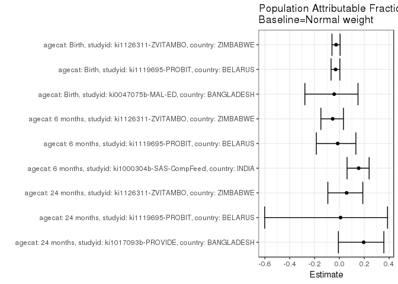

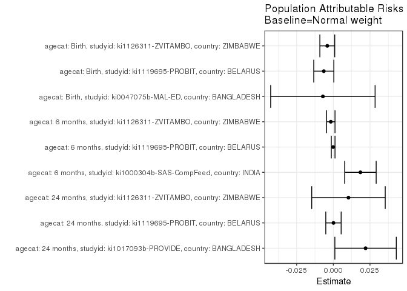

## Results Table

### Parameter: TSM

| agecat | studyid | country | intervention_level | baseline_level | estimate | ci_lower | ci_upper |
| --- | --- | --- | --- | --- | --- | --- | --- |
| Birth | ki0047075b-MAL-ED | BANGLADESH | Normal weight | NA | 0.1744966 | 0.1134247 | 0.2355686 |
| Birth | ki0047075b-MAL-ED | BANGLADESH | Underweight | NA | 0.2500000 | 0.0892675 | 0.4107325 |
| Birth | ki0047075b-MAL-ED | BANGLADESH | Overweight or Obese | NA | 0.1071429 | 0.0259607 | 0.1883250 |
| Birth | ki1119695-PROBIT | BELARUS | Normal weight | NA | 0.2152940 | 0.1502197 | 0.2803682 |
| Birth | ki1119695-PROBIT | BELARUS | Underweight | NA | 0.2750896 | 0.2084443 | 0.3417349 |
| Birth | ki1119695-PROBIT | BELARUS | Overweight or Obese | NA | 0.1944416 | 0.1294894 | 0.2593938 |
| Birth | ki1126311-ZVITAMBO | ZIMBABWE | Normal weight | NA | 0.1583904 | 0.1492849 | 0.1674958 |
| Birth | ki1126311-ZVITAMBO | ZIMBABWE | Underweight | NA | 0.2140374 | 0.1809859 | 0.2470889 |
| Birth | ki1126311-ZVITAMBO | ZIMBABWE | Overweight or Obese | NA | 0.1328479 | 0.1190669 | 0.1466289 |
| 6 months | ki1000304b-SAS-CompFeed | INDIA | Normal weight | NA | 0.1007026 | 0.0762430 | 0.1251622 |
| 6 months | ki1000304b-SAS-CompFeed | INDIA | Underweight | NA | 0.1677632 | 0.1105003 | 0.2250260 |
| 6 months | ki1000304b-SAS-CompFeed | INDIA | Overweight or Obese | NA | 0.1343284 | 0.0015521 | 0.2671046 |
| 6 months | ki1119695-PROBIT | BELARUS | Normal weight | NA | 0.0080207 | 0.0053399 | 0.0107015 |
| 6 months | ki1119695-PROBIT | BELARUS | Underweight | NA | 0.0099010 | -0.0006297 | 0.0204317 |
| 6 months | ki1119695-PROBIT | BELARUS | Overweight or Obese | NA | 0.0075172 | 0.0052547 | 0.0097798 |
| 6 months | ki1126311-ZVITAMBO | ZIMBABWE | Normal weight | NA | 0.0331767 | 0.0280867 | 0.0382666 |
| 6 months | ki1126311-ZVITAMBO | ZIMBABWE | Underweight | NA | 0.0803639 | 0.0580239 | 0.1027039 |
| 6 months | ki1126311-ZVITAMBO | ZIMBABWE | Overweight or Obese | NA | 0.0232897 | 0.0163799 | 0.0301995 |
| 24 months | ki1017093b-PROVIDE | BANGLADESH | Normal weight | NA | 0.0906593 | 0.0611375 | 0.1201812 |
| 24 months | ki1017093b-PROVIDE | BANGLADESH | Underweight | NA | 0.2500000 | 0.1650574 | 0.3349426 |
| 24 months | ki1017093b-PROVIDE | BANGLADESH | Overweight or Obese | NA | 0.0619469 | 0.0174624 | 0.1064314 |
| 24 months | ki1119695-PROBIT | BELARUS | Normal weight | NA | 0.0108085 | 0.0054718 | 0.0161451 |
| 24 months | ki1119695-PROBIT | BELARUS | Underweight | NA | 0.0354610 | 0.0131895 | 0.0577325 |
| 24 months | ki1119695-PROBIT | BELARUS | Overweight or Obese | NA | 0.0087424 | -0.0050408 | 0.0225257 |
| 24 months | ki1126311-ZVITAMBO | ZIMBABWE | Normal weight | NA | 0.1679389 | 0.1226120 | 0.2132659 |
| 24 months | ki1126311-ZVITAMBO | ZIMBABWE | Underweight | NA | 0.3200000 | 0.1368895 | 0.5031105 |
| 24 months | ki1126311-ZVITAMBO | ZIMBABWE | Overweight or Obese | NA | 0.1666667 | 0.0804639 | 0.2528695 |

### Parameter: E(Y)

| agecat | studyid | country | intervention_level | baseline_level | estimate | ci_lower | ci_upper |
| --- | --- | --- | --- | --- | --- | --- | --- |
| Birth | ki0047075b-MAL-ED | BANGLADESH | NA | NA | 0.1673820 | 0.1193444 | 0.2154196 |
| Birth | ki1119695-PROBIT | BELARUS | NA | NA | 0.2087968 | 0.1432289 | 0.2743648 |
| Birth | ki1126311-ZVITAMBO | ZIMBABWE | NA | NA | 0.1542807 | 0.1468295 | 0.1617318 |
| 6 months | ki1000304b-SAS-CompFeed | INDIA | NA | NA | 0.1191837 | 0.0947144 | 0.1436529 |
| 6 months | ki1119695-PROBIT | BELARUS | NA | NA | 0.0079085 | 0.0059160 | 0.0099010 |
| 6 months | ki1126311-ZVITAMBO | ZIMBABWE | NA | NA | 0.0314661 | 0.0274014 | 0.0355307 |
| 24 months | ki1017093b-PROVIDE | BANGLADESH | NA | NA | 0.1126516 | 0.0868319 | 0.1384714 |
| 24 months | ki1119695-PROBIT | BELARUS | NA | NA | 0.0109109 | 0.0040853 | 0.0177366 |
| 24 months | ki1126311-ZVITAMBO | ZIMBABWE | NA | NA | 0.1782730 | 0.1386257 | 0.2179202 |

### Parameter: RR

| agecat | studyid | country | intervention_level | baseline_level | estimate | ci_lower | ci_upper |
| --- | --- | --- | --- | --- | --- | --- | --- |
| Birth | ki0047075b-MAL-ED | BANGLADESH | Normal weight | Normal weight | 1.0000000 | 1.0000000 | 1.0000000 |
| Birth | ki0047075b-MAL-ED | BANGLADESH | Underweight | Normal weight | 1.4326923 | 0.6890349 | 2.9789598 |
| Birth | ki0047075b-MAL-ED | BANGLADESH | Overweight or Obese | Normal weight | 0.6140110 | 0.2665031 | 1.4146533 |
| Birth | ki1119695-PROBIT | BELARUS | Normal weight | Normal weight | 1.0000000 | 1.0000000 | 1.0000000 |
| Birth | ki1119695-PROBIT | BELARUS | Underweight | Normal weight | 1.2777396 | 1.0737828 | 1.5204364 |
| Birth | ki1119695-PROBIT | BELARUS | Overweight or Obese | Normal weight | 0.9031447 | 0.8299318 | 0.9828162 |
| Birth | ki1126311-ZVITAMBO | ZIMBABWE | Normal weight | Normal weight | 1.0000000 | 1.0000000 | 1.0000000 |
| Birth | ki1126311-ZVITAMBO | ZIMBABWE | Underweight | Normal weight | 1.3513285 | 1.1461098 | 1.5932931 |
| Birth | ki1126311-ZVITAMBO | ZIMBABWE | Overweight or Obese | Normal weight | 0.8387371 | 0.7449789 | 0.9442950 |
| 6 months | ki1000304b-SAS-CompFeed | INDIA | Normal weight | Normal weight | 1.0000000 | 1.0000000 | 1.0000000 |
| 6 months | ki1000304b-SAS-CompFeed | INDIA | Underweight | Normal weight | 1.6659272 | 1.1556173 | 2.4015851 |
| 6 months | ki1000304b-SAS-CompFeed | INDIA | Overweight or Obese | Normal weight | 1.3339118 | 0.4953386 | 3.5921303 |
| 6 months | ki1119695-PROBIT | BELARUS | Normal weight | Normal weight | 1.0000000 | 1.0000000 | 1.0000000 |
| 6 months | ki1119695-PROBIT | BELARUS | Underweight | Normal weight | 1.2344299 | 0.3846571 | 3.9614953 |
| 6 months | ki1119695-PROBIT | BELARUS | Overweight or Obese | Normal weight | 0.9372285 | 0.6460018 | 1.3597443 |
| 6 months | ki1126311-ZVITAMBO | ZIMBABWE | Normal weight | Normal weight | 1.0000000 | 1.0000000 | 1.0000000 |
| 6 months | ki1126311-ZVITAMBO | ZIMBABWE | Underweight | Normal weight | 2.4222995 | 1.7637727 | 3.3266956 |
| 6 months | ki1126311-ZVITAMBO | ZIMBABWE | Overweight or Obese | Normal weight | 0.7019902 | 0.5026626 | 0.9803598 |
| 24 months | ki1017093b-PROVIDE | BANGLADESH | Normal weight | Normal weight | 1.0000000 | 1.0000000 | 1.0000000 |
| 24 months | ki1017093b-PROVIDE | BANGLADESH | Underweight | Normal weight | 2.7575758 | 1.7224250 | 4.4148360 |
| 24 months | ki1017093b-PROVIDE | BANGLADESH | Overweight or Obese | Normal weight | 0.6832931 | 0.3105776 | 1.5032939 |
| 24 months | ki1119695-PROBIT | BELARUS | Normal weight | Normal weight | 1.0000000 | 1.0000000 | 1.0000000 |
| 24 months | ki1119695-PROBIT | BELARUS | Underweight | Normal weight | 3.2808511 | 1.6636537 | 6.4700868 |
| 24 months | ki1119695-PROBIT | BELARUS | Overweight or Obese | Normal weight | 0.8088500 | 0.1723322 | 3.7963787 |
| 24 months | ki1126311-ZVITAMBO | ZIMBABWE | Normal weight | Normal weight | 1.0000000 | 1.0000000 | 1.0000000 |
| 24 months | ki1126311-ZVITAMBO | ZIMBABWE | Underweight | Normal weight | 1.9054545 | 1.0121143 | 3.5872994 |
| 24 months | ki1126311-ZVITAMBO | ZIMBABWE | Overweight or Obese | Normal weight | 0.9924242 | 0.5537686 | 1.7785512 |

### Parameter: PAR

| agecat | studyid | country | intervention_level | baseline_level | estimate | ci_lower | ci_upper |
| --- | --- | --- | --- | --- | --- | --- | --- |
| Birth | ki0047075b-MAL-ED | BANGLADESH | Normal weight | NA | -0.0071147 | -0.0427112 | 0.0284819 |
| Birth | ki1119695-PROBIT | BELARUS | Normal weight | NA | -0.0064971 | -0.0133468 | 0.0003525 |
| Birth | ki1126311-ZVITAMBO | ZIMBABWE | Normal weight | NA | -0.0041097 | -0.0091835 | 0.0009641 |
| 6 months | ki1000304b-SAS-CompFeed | INDIA | Normal weight | NA | 0.0184811 | 0.0077445 | 0.0292177 |
| 6 months | ki1119695-PROBIT | BELARUS | Normal weight | NA | -0.0001122 | -0.0013735 | 0.0011490 |
| 6 months | ki1126311-ZVITAMBO | ZIMBABWE | Normal weight | NA | -0.0017106 | -0.0045696 | 0.0011483 |
| 24 months | ki1017093b-PROVIDE | BANGLADESH | Normal weight | NA | 0.0219923 | 0.0010500 | 0.0429346 |
| 24 months | ki1119695-PROBIT | BELARUS | Normal weight | NA | 0.0001025 | -0.0051318 | 0.0053368 |
| 24 months | ki1126311-ZVITAMBO | ZIMBABWE | Normal weight | NA | 0.0103340 | -0.0147183 | 0.0353864 |

### Parameter: PAF

| agecat | studyid | country | intervention_level | baseline_level | estimate | ci_lower | ci_upper |
| --- | --- | --- | --- | --- | --- | --- | --- |
| Birth | ki0047075b-MAL-ED | BANGLADESH | Normal weight | NA | -0.0425056 | -0.2781677 | 0.1497063 |
| Birth | ki1119695-PROBIT | BELARUS | Normal weight | NA | -0.0311169 | -0.0671030 | 0.0036556 |
| Birth | ki1126311-ZVITAMBO | ZIMBABWE | Normal weight | NA | -0.0266378 | -0.0600544 | 0.0057253 |
| 6 months | ki1000304b-SAS-CompFeed | INDIA | Normal weight | NA | 0.1550640 | 0.0615562 | 0.2392546 |
| 6 months | ki1119695-PROBIT | BELARUS | Normal weight | NA | -0.0141901 | -0.1855851 | 0.1324271 |
| 6 months | ki1126311-ZVITAMBO | ZIMBABWE | Normal weight | NA | -0.0543642 | -0.1491486 | 0.0326021 |
| 24 months | ki1017093b-PROVIDE | BANGLADESH | Normal weight | NA | 0.1952240 | -0.0084577 | 0.3577674 |
| 24 months | ki1119695-PROBIT | BELARUS | Normal weight | NA | 0.0093908 | -0.6017331 | 0.3873470 |
| 24 months | ki1126311-ZVITAMBO | ZIMBABWE | Normal weight | NA | 0.0579676 | -0.0931772 | 0.1882148 |